# CEE6501 — Lecture 6.2

## 2D Beam Element Stiffness Matrix

## Learning Objectives

By the end of this lecture, you will be able to:

- Define the local DOFs and sign conventions for a 2D Euler–Bernoulli beam element
- Interpret the member stiffness relation $\mathbf{Q} = \mathbf{k}\mathbf{u}$ in a physical sense
- Compute stiffness coefficients using the unit displacement method and understand their meaning
- Recognize and use the standard 4×4 beam element stiffness matrix
- Evaluate and visualize beam deformation using shape functions and nodal DOFs
- Understand how beam elements are assembled into a global DSM system

## Agenda

Part 1 — Beam element stiffness relations and local DOFs  
Part 2 — Derive Column 1 (unit displacement method)  
Part 3 — Complete the 4×4 beam stiffness matrix  
Part 4 — Beam deformation patterns and shape functions  
Part 5 — DSM setup and element-to-global mapping

## Part 1 — Beam Element Stiffness Relations

### Beam Element Response

The **member stiffness relations** express the end forces of a beam element  
(including shear forces and bending moments) as functions of the **end displacements**  
(including transverse displacements and rotations).

When a beam element is subjected to external loading:

- The member **deforms** (bending)
- **Internal shear forces** develop at the ends
- **Bending moments** are induced at the ends

These internal forces are fully determined by the **displacements and rotations at the element ends**.

### Generic Displacement for a 2D Beam Element

We define all quantities in the **local coordinate system**, with origin at the left end $b$, and ending at node $e$.

[figure not shown]

### 2D Beam Element DOF Numbering

Degrees of freedom are ordered **left → right**, with **translation first**, then **rotation**.

[figure not shown]

- **DOF 1:** $u_1$ — node $b$, local $y$
- **DOF 2:** $u_2$ — node $b$, $\theta$
- **DOF 3:** $u_3$ — node $e$, local $y$
- **DOF 4:** $u_4$ — node $e$, $\theta$

**Sign conventions:**

- $+u$ → upward (local $y$ direction)
- $+\theta$ → counterclockwise
- Forces follow the same order: $[V_b,\ M_b,\ V_e,\ M_e]^T$

### Local displacement and force vectors

Local displacement vector (including rotations): $$ \boldsymbol{u}= \begin{Bmatrix} u_b\\ \theta_b\\ u_e\\ \theta_e \end{Bmatrix} = \begin{Bmatrix} u_1\\ u_2\\ u_3\\ u_4 \end{Bmatrix} $$

Local nodal force vector (including moments): $$ \boldsymbol{Q} = \begin{Bmatrix} V_b\\ M_b\\ V_e\\ M_e \end{Bmatrix} = \begin{Bmatrix} Q_1\\ Q_2\\ Q_3\\ Q_4 \end{Bmatrix} $$

We seek: $$\boldsymbol{Q} = \boldsymbol{k}\,\boldsymbol{u}$$

### Four equations (one per DOF)

Recall: this is similar in spirit to the truss element definition.

$$ Q_1 = k_{11}u_1 + k_{12}u_2 + k_{13}u_3 + k_{14}u_4 $$ $$ Q_2 = k_{21}u_1 + k_{22}u_2 + k_{23}u_3 + k_{24}u_4 $$ $$ Q_3 = k_{31}u_1 + k_{32}u_2 + k_{33}u_3 + k_{34}u_4 $$ $$ Q_4 = k_{41}u_1 + k_{42}u_2 + k_{43}u_3 + k_{44}u_4 $$

Each equation expresses **force equilibrium at a single local degree of freedom**.

For a linear elastic element, the force at any DOF is a **linear combination** of all DOF displacements:

- displacing one DOF can induce forces at *all* DOFs
- the proportionality constants are the stiffness coefficients $k_{ij}$

### Same equations in matrix form

$$ \begin{Bmatrix} Q_1\\ Q_2\\ Q_3\\ Q_4 \end{Bmatrix} = \begin{bmatrix} k_{11} & k_{12} & k_{13} & k_{14}\\ k_{21} & k_{22} & k_{23} & k_{24}\\ k_{31} & k_{32} & k_{33} & k_{34}\\ k_{41} & k_{42} & k_{43} & k_{44} \end{bmatrix} \begin{Bmatrix} u_1\\ u_2\\ u_3\\ u_4 \end{Bmatrix} $$

## Part 2 — Derive Column 1 of the Beam Element Stiffness Matrix

### Unit Displacement Method

Definition: $$ k_{ij} = \text{force at DOF } i \text{ due to a unit displacement at DOF } j, \text{ with all other DOFs fixed.} $$

Each column of $\boldsymbol{k}$ is built by:

- impose a **unit displacement/rotation** at one DOF
- hold all other DOFs fixed
- record the resulting nodal force pattern

### Column 1: impose $u_1 = 1$ ($u_2 = u_3 = u_4 = 0$)

$$ \begin{bmatrix} \boxed{k_{11}} & k_{12} & k_{13} & k_{14}\\ \boxed{k_{21}} & k_{22} & k_{23} & k_{24}\\ \boxed{k_{31}} & k_{32} & k_{33} & k_{34}\\ \boxed{k_{41}} & k_{42} & k_{43} & k_{44} \end{bmatrix} $$

- $k_{11}$: force at DOF 1 due to unit displacement at DOF 1
- $k_{21}$: force at DOF 2 due to unit displacement at DOF 1
- $k_{31}$: force at DOF 3 due to unit displacement at DOF 1
- $k_{41}$: force at DOF 4 due to unit displacement at DOF 1

### Column 1: impose $u_1 = 1$ ($u_2 = u_3 = u_4 = 0$)

[figure not shown]

### Sign Convention for Derivation

[figure not shown]

### Governing Equation (Beam Bending)

\begin{equation} \frac{d^2 u}{dx^2} = \frac{M(x)}{EI} \tag{1} \end{equation}

- $u(x)$ = transverse displacement
- $M(x)$ = bending moment
- $EI$ = flexural rigidity

### Step 1 — Express Internal Moment as a Function of $x$

[figure not shown]

Cut the beam at a distance $x$ from node $b$.

Using equilibrium: \begin{equation} M(x) = -k_{21} + k_{11} x \tag{2} \end{equation}

- $k_{21}$: end moment at node $b$
- $k_{11}$: end shear at node $b$

### Step 2 — Substitute into Governing Equation

Substitute Eq. (2) into the **moment term** of Eq. (1):

\begin{equation} \frac{d^2 u}{dx^2} = \frac{M(x)}{EI} \;\;\xrightarrow{\text{Eq. (2)}}\;\; \frac{d^2 u}{dx^2} = \frac{1}{EI} \left(-k_{21} + k_{11} x \right) \tag{3} \end{equation}

### Step 3 — Integrate to Obtain Rotation $\theta(x)$

Start from Eq. (3): \begin{equation} \frac{d^2 u}{dx^2} = \frac{1}{EI}\left(-k_{21} + k_{11}x\right) \tag{3} \end{equation}

Integrate both sides with respect to $x$:

\begin{equation} \int \frac{d^2 u}{dx^2}\,dx = \int \frac{1}{EI}\left(-k_{21} + k_{11}x\right)\,dx \tag{4a} \end{equation}

Left-hand side: \begin{equation} \int \frac{d^2 u}{dx^2}\,dx = \frac{du}{dx} = \theta(x) \tag{4b} \end{equation}

Right-hand side (term-by-term):

$$ \begin{equation} \int \frac{1}{EI}\left(-k_{21} + k_{11}x\right)\,dx = \frac{1}{EI}\left(\int -k_{21}\,dx + \int k_{11}x\,dx\right) \tag{4c} \end{equation} $$

Compute:

$$ \begin{equation} \int -k_{21}\,dx = -k_{21}x \qquad \int k_{11}x\,dx = \frac{k_{11}}{2}x^2 \tag{4d} \end{equation} $$

Include integration constant $C_1$:

$$ \begin{equation} \theta(x)=\frac{du}{dx} = \frac{1}{EI}\left(-k_{21}x+\frac{k_{11}}{2}x^2\right)+C_1 \tag{4} \end{equation} $$

### Step 4 — Integrate to Obtain Displacement $u(x)$

Start from Eq. (4): $$ \begin{equation} \frac{du}{dx} = \frac{1}{EI}\left(-k_{21}x+\frac{k_{11}}{2}x^2\right)+C_1 \tag{4} \end{equation} $$

Integrate both sides with respect to $x$: $$ \begin{equation} \int \frac{du}{dx}\,dx = \int \left[ \frac{1}{EI}\left(-k_{21}x+\frac{k_{11}}{2}x^2\right)+C_1 \right] dx \tag{5a} \end{equation} $$

Left-hand side: $$ \begin{equation} \int \frac{du}{dx}\,dx = u(x) \tag{5b} \end{equation} $$

Right-hand side (compact form):

$$ \begin{equation} u(x)= \frac{1}{EI}\left(\int -k_{21}x\,dx + \int \frac{k_{11}}{2}x^2\,dx\right) + \int C_1\,dx \tag{5c} \end{equation} $$

Compute: $$ \begin{equation} \int -k_{21}x\,dx = -\frac{k_{21}}{2}x^2 \qquad \int \frac{k_{11}}{2}x^2\,dx = \frac{k_{11}}{6}x^3 \qquad \int C_1\,dx = C_1 x \tag{5d} \end{equation} $$

Include integration constant $C_2$: $$ \begin{equation} u(x)= \frac{1}{EI}\left(-\frac{k_{21}}{2}x^2+\frac{k_{11}}{6}x^3\right) + C_1 x + C_2 \tag{5} \end{equation} $$

### Step 5 — Apply Boundary Conditions

We enforce **unit displacement at node $b$** (0 elsewhere):

At $x = 0$: \begin{align*} \theta(0) &= 0 \\ u(0) &= 1 \end{align*}

At $x = L$: \begin{align*} \theta(L) &= 0 \\ u(L) &= 0 \end{align*}

### Step 6 — Solve for Constants

Substitute $x=0$ into Eqs. (4)–(5):

- From $\theta(0) = 0$: all terms with $x$ vanish $\Rightarrow C_1 = 0$
- From $u(0) = 1$: all terms with $x$ vanish $\Rightarrow C_2 = 1$

Updated Eqs. (4)–(5): \begin{equation} \theta(x) = \frac{1}{EI} \left(-k_{21} x + \frac{k_{11}}{2} x^2 \right) \tag{6} \end{equation}

\begin{equation} u(x) = \frac{1}{EI} \left(-\frac{k_{21}}{2} x^2 + \frac{k_{11}}{6} x^3 \right) + 1 \tag{7} \end{equation}

### Step 7 — Apply Boundary Condition at $x = L$

Substitute $\theta(L)=0$ into Eq. (6): $$ \begin{equation*} 0 = \frac{1}{EI} \left(-k_{21} L + \frac{k_{11}}{2} L^2 \right) \end{equation*} $$

Cancel $EI$ and solve: $$ \begin{equation*} k_{21} = \frac{k_{11}L}{2} \tag{8} \end{equation*} $$

### Step 8 — Apply Final Condition

Substitute $u(L)=0$ into Eq. (7): $$ \begin{equation*} 0 = \frac{1}{EI}\left(-\frac{k_{21}}{2}L^2+\frac{k_{11}}{6}L^3\right)+1 \tag{9} \end{equation*} $$

Substitute Eq. (8) into Eq. (9) and solve: $$ \begin{equation*} \boxed{\;k_{11} = \frac{12EI}{L^3}\;} \end{equation*} $$

### Step 9 — Solve for $k_{21}$

Back-substitute $k_{11}$ into Eq. (8): \begin{equation*} \boxed{\;k_{21} = \frac{6EI}{L^2}\;} \end{equation*}

### Step 10 — Solve Remaining Stiffness Terms $k_{31}$ and $k_{41}$

Use equilibrium of the beam element free-body diagram (with $k_{11}$ and $k_{21}$ known).

**Vertical force equilibrium** \begin{equation*} \sum F_y=0:\qquad \frac{12EI}{L^3}+k_{31}=0 \end{equation*} \begin{equation*} \boxed{\;k_{31}=-\frac{12EI}{L^3}\;} \end{equation*}

**Moment equilibrium about node $b$** \begin{equation*} \sum M_b=0:\qquad \frac{6EI}{L^2}-\left(\frac{12EI}{L^3}\right)L+k_{41}=0 \end{equation*} \begin{equation*} \boxed{\;k_{41}=\frac{6EI}{L^2}\;} \end{equation*}

[figure not shown]

Free-body diagram used for $\sum F_y=0$ and $\sum M_b=0$.

### Step 11 (Optional) — Displacement Shape Function

Substitute $k_{11}$ and $k_{21}$ into Eq. (7): \begin{equation*} u(x)=1-3\left(\frac{x}{L}\right)^2+2\left(\frac{x}{L}\right)^3 \end{equation*}

### Column 1 of the 4×4 Stiffness Matrix

$$ \boldsymbol{k}= \begin{bmatrix} \boxed{\dfrac{12EI}{L^3}} & k_{12} & k_{13} & k_{14} \\ \boxed{\dfrac{6EI}{L^2}} & k_{22} & k_{23} & k_{24} \\ \boxed{-\dfrac{12EI}{L^3}} & k_{32} & k_{33} & k_{34} \\ \boxed{\dfrac{6EI}{L^2}} & k_{42} & k_{43} & k_{44} \end{bmatrix} $$

## Part 3 — Complete 4×4 Beam Stiffness Matrix

### Column 2: impose $u_2 = 1$ ($u_1 = u_3 = u_4 = 0$)

[figure not shown]

### Column 3: impose $u_3 = 1$ ($u_1 = u_2 = u_4 = 0$)

[figure not shown]

### Column 4: impose $u_4 = 1$ ($u_1 = u_2 = u_3 = 0$)

[figure not shown]

### Complete 4×4 Beam Element Stiffness Matrix

$$ \mathbf{k} = \frac{EI}{L^3} \begin{bmatrix} 12 & 6L & -12 & 6L \\ 6L & 4L^2 & -6L & 2L^2 \\ -12 & -6L & 12 & -6L \\ 6L & 2L^2 & -6L & 4L^2 \end{bmatrix} $$

## Part 4 - Beam Deformation Patterns

### Displacement Field

A 2D beam element has **4 DOFs**, so the displacement field is written as a superposition:

$$ u(x) = N_1(x)\,u_1 + N_2(x)\,u_2 + N_3(x)\,u_3 + N_4(x)\,u_4 $$

Here, $u(x)$ represents the **transverse displacement of the beam in the local $y$-direction**.

Each $N_i(x)$ is a **shape function** (a deformation pattern) associated with one DOF:

- $N_1(x)$: unit transverse displacement at node $b$
- $N_2(x)$: unit rotation at node $b$
- $N_3(x)$: unit transverse displacement at node $e$
- $N_4(x)$: unit rotation at node $e$

### The 4 Shape Functions

We derived $N_1$ earlier: $$ N_1(x)=1-3\left(\frac{x}{L}\right)^2+2\left(\frac{x}{L}\right)^3 $$

The shape functions for the other DOFs: $$ N_2(x)=x-2\frac{x^2}{L}+\frac{x^3}{L^2} $$

$$ N_3(x)=3\left(\frac{x}{L}\right)^2-2\left(\frac{x}{L}\right)^3 $$

$$ N_4(x)=-\frac{x^2}{L}+\frac{x^3}{L^2} $$

### Connection to the Finite Element Method (FEM)

The shape functions we derived are exactly those used in the **Finite Element Method (FEM)** for beam elements.

- In FEM, the displacement field is approximated as: $$ u(x) = \sum_{i=1}^4 N_i(x)\,u_i $$
- The unknowns are the same **nodal DOFs** $\{u_1,u_2,u_3,u_4\}$
- Shape functions provide a **continuous interpolation** within the element

In **CEE6501**, we focus on the **Direct Stiffness Method (DSM)** and derive the stiffness matrix using structural mechanics.

But for the FEM-based derivation of the beam stiffness matrix, see:

- **Kassimali**, Section 5.3

### Plotting a Deformed Shape

While we do not explicitly use shape functions in the **DSM formulation**, they are very useful for **visualizing structural response**.

Given element DOFs $$ \boldsymbol{u}=\{u_1,\ u_2,\ u_3,\ u_4\}^T, $$ we can evaluate the displacement field $$ u(x) = \sum_{i=1}^4 N_i(x)\,u_i $$ at many points along $x \in [0, L]$ to obtain a smooth deformation curve.

### Why This Is Useful

- Visualize the **continuous beam deflection** (not just nodal values)
- Check **sign conventions** and DOF interpretation
- Construct smooth **deformed shapes for multi-element structures**

```python
import numpy as np
import matplotlib.pyplot as plt

def shape_functions(x, L):
    xi = x / L
    N1 = 1 - 3*xi**2 + 2*xi**3
    N2 = L * (xi - 2*xi**2 + xi**3)
    N3 = 3*xi**2 - 2*xi**3
    N4 = L * (-xi**2 + xi**3)
    return N1, N2, N3, N4

def beam_deflection(x, L, u1, u2, u3, u4):
    """
    Compute beam transverse deflection u(x) from nodal DOFs.
    DOFs: u1 (disp at b), u2 (rot at b), u3 (disp at e), u4 (rot at e)
    """
    N1, N2, N3, N4 = shape_functions(x, L)
    return N1*u1 + N2*u2 + N3*u3 + N4*u4
```

```python
def plot_beam(L, u1, u2, u3, u4, n=200):
    x = np.linspace(0, L, n)
    u = beam_deflection(x, L, u1, u2, u3, u4)

    plt.figure(figsize=(6, 2.5))  # smaller plot

    # undeformed shape
    plt.plot(x, np.zeros_like(x), linestyle="-", label="undeformed")
    plt.scatter([0, L], [0, 0])  # nodes (no legend)

    # deformed shape
    plt.plot(x, u, color="red", label="deformed")
    plt.scatter([0, L], [u1, u3])  # nodes (no legend)

    plt.xlabel("x (m)")
    plt.ylabel("u(x)")
    plt.title("Beam Deformed Shape")
    plt.legend()
    plt.show()
```

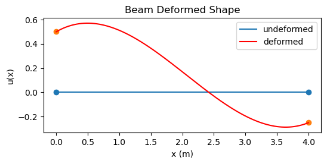

```python
L = 4.0  # element length

# Example nodal DOFs (pick anything to test)
u1 = 0.5  # displacement at node b
u2 = +0.3   # rotation at node b (rad)
u3 = -0.25  # displacement at node e
u4 = 0.21   # rotation at node e (rad)

plot_beam(L, u1, u2, u3, u4)
```

## Part 5 - DSM Setup

### Global System (Same as Trusses)

The overall system still follows the standard **Direct Stiffness Method**:

$$ \boldsymbol{K}\,\boldsymbol{u} = \boldsymbol{f} $$

Separating **free** and **restrained** DOFs:

$$ \scriptsize{ \left[ \begin{array}{c:c} \boldsymbol{K}_{ff} & \boldsymbol{K}_{fr}\\ \hdashline \boldsymbol{K}_{rf} & \boldsymbol{K}_{rr} \end{array} \right] \left\{ \begin{array}{c} \boldsymbol{u}_f\\ \hdashline \boldsymbol{u}_r \end{array} \right\} = \left\{ \begin{array}{c} \boldsymbol{F}_f\\ \hdashline \boldsymbol{F}_r \end{array} \right\} } $$

Here the dashed line shows the split between free and restrained DOFs:

- top-left block: $\boldsymbol{K}_{ff}$ (free–free)
- top-right block: $\boldsymbol{K}_{fr}$ (free–restrained)
- bottom-left block: $\boldsymbol{K}_{rf}$ (restrained–free)
- bottom-right block: $\boldsymbol{K}_{rr}$ (restrained–restrained)

### Example Structure 1

Same beam as in 6.1

[figure not shown]

### DSM Assembly — Element-to-Global Mapping (Unpartitioned)

[figure not shown]

Element 1 mapping

[figure not shown]

Element 2 mapping

[figure not shown]

Element 3 mapping

DOFs 4,5,6 are free, partition the matrix in that way

### Example Structure 2

[figure not shown]

### DSM Assembly — Element-to-Global Mapping (Partitioned System)

$$ \scriptsize{ \left[ \begin{array}{c:c} \boldsymbol{K}_{ff} & \boldsymbol{K}_{fr}\\ \hdashline \boldsymbol{K}_{rf} & \boldsymbol{K}_{rr} \end{array} \right] \left\{ \begin{array}{c} u_a\\ \theta_a\\ \theta_b\\ \theta_c\\ \hdashline 0\\ 0\\ 0\\ 0 \end{array} \right\} = \left\{ \begin{array}{c} -P\\ 0\\ 0\\ 0\\ \hdashline R_{yb}\\ R_{yc}\\ R_{yd}\\ R_{md} \end{array} \right\} } $$

[figure not shown]

**Free DOFs (Global Indexing):**

- $u_a$ → DOF 1
- $\theta_a$ → DOF 2
- $\theta_b$ → DOF 4
- $\theta_c$ → DOF 6

**Reactions (Global Indexing):**

- $R_{yb}$ → DOF 3
- $R_{yc}$ → DOF 5
- $R_{yd}$ → DOF 7
- $R_{md}$ → DOF 8

### Solving for $u_f$ (Review)

We are interested in solving for the **unknown displacements** at the free DOFs, $\boldsymbol{u}_f$.

Starting from:

$$ \boldsymbol{K}_{ff}\boldsymbol{u}_f+\boldsymbol{K}_{fr}\boldsymbol{u}_r=\boldsymbol{F}_f $$

Rearrange to isolate the unknowns: $$ \boldsymbol{K}_{ff}\boldsymbol{u}_f = \boldsymbol{F}_f - \boldsymbol{K}_{fr}\boldsymbol{u}_r $$

Provided that $\boldsymbol{K}_{ff}$ is invertible, the solution is: $$ \boxed{ \boldsymbol{u}_f = \boldsymbol{K}_{ff}^{-1} \Bigl( \boldsymbol{F}_f - \boldsymbol{K}_{fr}\boldsymbol{u}_r \Bigr) } $$

### Solving for $F_r$ (Review)

Once the free displacements $\boldsymbol{u}_f$ have been computed, we can determine the **forces at the restrained DOFs** (support reactions).

Starting from:

$\boldsymbol{K}_{rf}\boldsymbol{u}_f + \boldsymbol{K}_{rr}\boldsymbol{u}_r = \boldsymbol{F}_r$

At the restrained DOFs, the displacements $\boldsymbol{u}_r$ are **known** from the boundary conditions (often $\boldsymbol{u}_r=\boldsymbol{0}$). Substituting these known values gives a direct expression for the reaction forces: $$ \boxed{ \boldsymbol{F}_r = \boldsymbol{K}_{rf}\boldsymbol{u}_f + \boldsymbol{K}_{rr}\boldsymbol{u}_r } $$

## Wrap-Up

In this lecture, we:

- Defined the local beam DOFs and the local displacement and force vectors
- Built stiffness coefficients using the unit displacement method (column-by-column)
- Arrived at the standard 4×4 Euler–Bernoulli beam element stiffness matrix
- Introduced shape functions to reconstruct a smooth deflected shape u(x) from nodal DOFs
- Reviewed DSM system setup and partitioning into free and restrained DOFs

Next lecture:

- Introduce member loads and convert them to equivalent nodal loads
- Solve for nodal displacements, then compute reactions and internal member forces
- Complete DSM workflow